# Basic overview of the datasets

## Loading datasets

```python
import numpy as np
import pandas as pd
from functools import reduce
from bokeh.plotting import figure, output_notebook, show
from bokeh.models import ColumnDataSource
from bokeh.layouts import row
```

```python
train_path = "../data/sales_train.csv.gz"
test_path = "../data/test.csv.gz"
items_path = "../data/items.csv"
items_categories_path = "../data/item_categories.csv"
shops_path = "../data/shops.csv"
```

```python
train = pd.read_csv(train_path)
test = pd.read_csv(test_path)
items = pd.read_csv(items_path)
item_categories = pd.read_csv(items_categories_path)
shops = pd.read_csv(shops_path)
```

## Taking a look at the datsets

```python
train.head(3)
```

|  | date | date_block_num | shop_id | item_id | item_price | item_cnt_day |
| --- | --- | --- | --- | --- | --- | --- |
| 0 | 02.01.2013 | 0 | 59 | 22154 | 999.0 | 1.0 |
| 1 | 03.01.2013 | 0 | 25 | 2552 | 899.0 | 1.0 |
| 2 | 05.01.2013 | 0 | 25 | 2552 | 899.0 | -1.0 |

```python
test.head(3)
```

|  | ID | shop_id | item_id |
| --- | --- | --- | --- |
| 0 | 0 | 5 | 5037 |
| 1 | 1 | 5 | 5320 |
| 2 | 2 | 5 | 5233 |

```python
items.head(3)
```

|  | item_name | item_id | item_category_id |
| --- | --- | --- | --- |
| 0 | ! ВО ВЛАСТИ НАВАЖДЕНИЯ (ПЛАСТ.) D | 0 | 40 |
| 1 | !ABBYY FineReader 12 Professional Edition Full... | 1 | 76 |
| 2 | ***В ЛУЧАХ СЛАВЫ (UNV) D | 2 | 40 |

```python
item_categories.head(3)
```

|  | item_category_name | item_category_id |
| --- | --- | --- |
| 0 | PC - Гарнитуры/Наушники | 0 |
| 1 | Аксессуары - PS2 | 1 |
| 2 | Аксессуары - PS3 | 2 |

```python
shops.head(3)
```

|  | shop_name | shop_id |
| --- | --- | --- |
| 0 | !Якутск Орджоникидзе, 56 фран | 0 |
| 1 | !Якутск ТЦ "Центральный" фран | 1 |
| 2 | Адыгея ТЦ "Мега" | 2 |

## Count/missing data statistics

```python
train[['date_block_num', 'item_price', 'item_cnt_day']].describe()
```

|  | date_block_num | item_price | item_cnt_day |
| --- | --- | --- | --- |
| count | 2.935849e+06 | 2.935849e+06 | 2.935849e+06 |
| mean | 1.456991e+01 | 8.908532e+02 | 1.242641e+00 |
| std | 9.422988e+00 | 1.729800e+03 | 2.618834e+00 |
| min | 0.000000e+00 | -1.000000e+00 | -2.200000e+01 |
| 25% | 7.000000e+00 | 2.490000e+02 | 1.000000e+00 |
| 50% | 1.400000e+01 | 3.990000e+02 | 1.000000e+00 |
| 75% | 2.300000e+01 | 9.990000e+02 | 1.000000e+00 |
| max | 3.300000e+01 | 3.079800e+05 | 2.169000e+03 |

Interesting insights:

- Item price seems to have negative value, perhaps it is a missing value
- Item count per day also have negative values, there could be some missing values (which would be a bit strange tbh, because one could simply not insert the row). The other option is that these are returns of the product. Not sure if these should be counted in.

```python
train.isna().apply(lambda col: col.sum())
```

```
date              0
date_block_num    0
shop_id           0
item_id           0
item_price        0
item_cnt_day      0
dtype: int64
```

No NaN values, which means some of these negative values may actually be missing ones.

Let's check if there are additional information for all items/categories/shops

```python
# Utility function for counts checking.
def calculate_counts(column_name, ref_sets, extension_set):
    ref_sets_ids = [set(ref[column_name]) for ref in ref_sets]
    ext_ids = set(extension_set[column_name])

    refs_union = reduce(lambda s1, s2: s1 | s2, ref_sets_ids)

    ref_counts = [len(ref) for ref in ref_sets_ids]
    ext_count = len(ext_ids)
    union_count = len(refs_union)
    intersection_count = len(ext_ids & refs_union)

    all_counts = ref_counts + [union_count, ext_count, intersection_count]
    res_index = ["Ref {}".format(i) for i in range(1, len(ref_sets) + 1)] +\
        ['Refs Union', 'Extension', 'Union x Extension']

    return pd.DataFrame({'Count': all_counts},
                        index=res_index)
```

```python
calculate_counts('item_id', [train, test], items)
```

|  | Count |
| --- | --- |
| Ref 1 | 21807 |
| Ref 2 | 5100 |
| Refs Union | 22170 |
| Extension | 22170 |
| Union x Extension | 22170 |

```python
calculate_counts('shop_id', [train, test], shops)
```

|  | Count |
| --- | --- |
| Ref 1 | 60 |
| Ref 2 | 42 |
| Refs Union | 60 |
| Extension | 60 |
| Union x Extension | 60 |

```python
calculate_counts('item_category_id', [items], item_categories)
```

|  | Count |
| --- | --- |
| Ref 1 | 84 |
| Refs Union | 84 |
| Extension | 84 |
| Union x Extension | 84 |

Looks good, there are no shops/categories/items that are in the datasets but do not exist in suplementary datasets.

```python
calculate_counts('item_id', [train], test)
```

|  | Count |
| --- | --- |
| Ref 1 | 21807 |
| Refs Union | 21807 |
| Extension | 5100 |
| Union x Extension | 4737 |

There are 363 items that appear in the test set but not in the train set

```python
calculate_counts('shop_id', [train], test)
```

|  | Count |
| --- | --- |
| Ref 1 | 60 |
| Refs Union | 60 |
| Extension | 42 |
| Union x Extension | 42 |

No shops missing though.

Number of categories per item

```python
items.groupby('item_id')['item_category_id'].count().max()
```

```
1
```

None of the items has more than one category, which is good.

## Training/test sets item/shops combinations comparison

One of the very important insights is that the test set seems to be pretty big comparing to item/shop combinations per month from training data.

```python
test.shape
```

```
(214200, 3)
```

```python
train_block_shop_item = pd.DataFrame(
    {'shop_item' :train['shop_id'].astype(str) + "_" + train['item_id'].astype(str)}
)
train_block_shop_item['date_block_num'] = train['date_block_num']
train_block_shop_item.groupby('date_block_num')[['shop_item']].nunique().transpose()
```

| date_block_num | 0 | 1 | 2 | 3 | 4 | 5 | 6 | 7 | 8 | 9 | ... | 24 | 25 | 26 | 27 | 28 | 29 | 30 | 31 | 32 | 33 |
| --- | --- | --- | --- | --- | --- | --- | --- | --- | --- | --- | --- | --- | --- | --- | --- | --- | --- | --- | --- | --- | --- |
| shop_item | 63224 | 59935 | 63977 | 54638 | 53296 | 56196 | 58035 | 58022 | 51575 | 51090 | ... | 46775 | 41390 | 40464 | 32875 | 32220 | 31909 | 33527 | 33486 | 29678 | 31531 |

1 rows × 34 columns

This obviously comes from the fact that the test set was prepared in such a way that it contains all combinations of shops and items from the month. Probably to avoid data leaks or provide additional challenge. Nevertheless, this means that there will be a need to extend the training set the same way (add all item/shop combinations for a month) in order to obtain proper validation setup using training data (at least for the validation set).

One of the approaches would be to set unknown combinations to 0 instead of predicting them, but that would only be reasonable if the item/shop combinations are pretty stable across months. Let's check out.

```python
item_shop_sets = train_block_shop_item.groupby('date_block_num')['shop_item'].\
    apply(lambda x: set(x.tolist())).tolist()

pd.DataFrame([len(old & new) / len(new) for old, new in zip(item_shop_sets, item_shop_sets[1:])]).transpose()
```

|  | 0 | 1 | 2 | 3 | 4 | 5 | 6 | 7 | 8 | 9 | ... | 23 | 24 | 25 | 26 | 27 | 28 | 29 | 30 | 31 | 32 |
| --- | --- | --- | --- | --- | --- | --- | --- | --- | --- | --- | --- | --- | --- | --- | --- | --- | --- | --- | --- | --- | --- |
| 0 | 0.432602 | 0.376729 | 0.455544 | 0.415228 | 0.400367 | 0.422917 | 0.449037 | 0.472283 | 0.41787 | 0.4226 | ... | 0.567825 | 0.483909 | 0.455911 | 0.462783 | 0.416977 | 0.425366 | 0.422525 | 0.42149 | 0.445414 | 0.372808 |

1 rows × 33 columns

Well, can't say this looks reasonable, differences are pretty huge, so this would be pretty much guessing. If the differences were around, say, 10%, I could give it a try.

But let's not give up that quickly, perhaps the shops/items characteristics are seasonal. Let's check this on monthly basis.

```python
pd.DataFrame([len(old & new) / len(new) for old, new in zip(item_shop_sets, item_shop_sets[12:])]).transpose()
```

|  | 0 | 1 | 2 | 3 | 4 | 5 | 6 | 7 | 8 | 9 | ... | 12 | 13 | 14 | 15 | 16 | 17 | 18 | 19 | 20 | 21 |
| --- | --- | --- | --- | --- | --- | --- | --- | --- | --- | --- | --- | --- | --- | --- | --- | --- | --- | --- | --- | --- | --- |
| 0 | 0.199025 | 0.198222 | 0.220365 | 0.191685 | 0.1906 | 0.20546 | 0.216605 | 0.227697 | 0.207308 | 0.202324 | ... | 0.220096 | 0.218193 | 0.224595 | 0.215939 | 0.222067 | 0.222069 | 0.218331 | 0.223467 | 0.207527 | 0.202404 |

1 rows × 22 columns

Even worse, I guess it will be best to leave it for a model to learn.

To complete this part:

Total number of product-shop combinations:

```python
items.shape[0]*shops.shape[0]
```

```
1330200
```

Product-shop combinations in train set

```python
train_combinations = train[['shop_id', 'item_id']].drop_duplicates()
train_combinations.shape[0]
```

```
424124
```

## Basic visualizations

```python
# some additional preprocessing of the data for easier analysis
unique_dates = pd.DataFrame({'date': train['date'].drop_duplicates()})
unique_dates['date_parsed'] = pd.to_datetime(unique_dates.date, format="%d.%m.%Y")
unique_dates['day'] = unique_dates['date_parsed'].apply(lambda d: d.day)
unique_dates['month'] = unique_dates['date_parsed'].apply(lambda d: d.month)
unique_dates['year'] = unique_dates['date_parsed'].apply(lambda d: d.year)

train_postproc = train.merge(unique_dates, on='date').sort_values('date_parsed')
```

```python
# Embedding Bokeh into jupyter notebook
output_notebook()
```

```python
def my_figure(**options):
    return figure(tools="hover,pan,wheel_zoom,box_zoom,reset", **options)
```

### Total sales throughout the years, month by month

```python
data = train_postproc.groupby(['year', 'month']).agg({'item_cnt_day': np.sum}).reset_index().pivot(index='month', columns='year', values='item_cnt_day')
data.plot(figsize=(12, 8))
```

[output not shown]

Generally negative trend from year by year, seasonal trends visible as well.

### Number of items per category

```python
data = items.groupby('item_category_id')['item_id'].count().reset_index(name='count')
data['item_category_id'] = data['item_category_id'].astype(str)
src = ColumnDataSource(data)
sorted_range = data.sort_values('count')['item_category_id'].astype(str).tolist()
TOOLTIPS = [
    ("index", "$index"),
    ("value", "@count")
]
p = my_figure(x_range = sorted_range, tooltips=TOOLTIPS, width=800, title="Number of items per category")
p.title.text_font_size = '16pt'
p.xaxis.major_tick_line_color=None
p.xaxis.major_label_text_font_size='0pt'
p.vbar('item_category_id', top='count', width=0.9, source=src)
show(p)
```

[interactive chart not shown]

```python
data[['count']].describe(percentiles=np.arange(0.1, 1, 0.1)).transpose()
```

|  | count | mean | std | min | 10% | 20% | 30.0% | 40% | 50% | 60% | 70% | 80% | 90% | max |
| --- | --- | --- | --- | --- | --- | --- | --- | --- | --- | --- | --- | --- | --- | --- |
| count | 84.0 | 263.928571 | 642.834626 | 1.0 | 4.0 | 6.6 | 11.7 | 20.8 | 43.5 | 148.8 | 229.2 | 323.0 | 568.9 | 5035.0 |

```python
item_category = data.nlargest(1, 'count')['item_category_id'].values[0]
item_categories[item_categories['item_category_id'] == int(item_category)]
```

|  | item_category_name | item_category_id |
| --- | --- | --- |
| 40 | Кино - DVD | 40 |

**The most popular category is "Cinema - DVD"**

### Item prices

```python
data = train[['item_price']].drop_duplicates().sort_values('item_price')
data['index'] = range(data.shape[0])
TOOLTIPS = [
    ("index", "$index"),
    ("value", "@item_price")
]
p = my_figure(tooltips=TOOLTIPS, title="Item prices", width=800)
p.title.text_font_size = '16pt'
src = ColumnDataSource(data)
src_top = ColumnDataSource(data[-50:])
p.line(x='index', y='item_price', source=src)
p.circle(x='index', y='item_price', size=3, source=src_top)
show(p)
```

[interactive chart not shown]

```python
data[['item_price']].describe(percentiles=np.arange(0.1, 1, 0.1)).transpose()
```

|  | count | mean | std | min | 10% | 20% | 30.0% | 40% | 50% | 60% | 70% | 80% | 90% | max |
| --- | --- | --- | --- | --- | --- | --- | --- | --- | --- | --- | --- | --- | --- | --- |
| item_price | 19993.0 | 2147.908697 | 4808.244672 | -1.0 | 183.004 | 312.916 | 454.48 | 638.966 | 866.02 | 1143.714667 | 1542.722 | 2282.666 | 3725.9125 | 307980.0 |

```python
item_id = train_postproc[train_postproc['item_price'] == int(data['item_price'].nlargest(1).values[0])]['item_id'].values[0]
items[items['item_id'] == item_id]
train_postproc[train_postproc['item_id'] == item_id]
```

|  | date | date_block_num | shop_id | item_id | item_price | item_cnt_day | date_parsed | day | month | year |
| --- | --- | --- | --- | --- | --- | --- | --- | --- | --- | --- |
| 1196154 | 13.12.2013 | 11 | 12 | 6066 | 307980.0 | 1.0 | 2013-12-13 | 13 | 12 | 2013 |

```python
items[items['item_id'] == item_id]
```

|  | item_name | item_id | item_category_id |
| --- | --- | --- | --- |
| 6066 | Radmin 3 - 522 лиц. | 6066 | 75 |

**The most expensive item in the dataset is a software license to Radmin 3. I believe they sold a pack of 522 licenses at once, that's why the price is so high.**

### Frequency of item sale

```python
data = train['item_id'].value_counts().sort_values().reset_index()
data.columns = ['item_id', 'count']
data['item_id'] = data['item_id'].astype(str)
TOOLTIPS = [
    ("index", "@x"),
    ("value", "@y")
]
p = my_figure(tooltips=TOOLTIPS, width=800, title="Frequency of items sale")
p.title.text_font_size = '16pt'
p.line(x=data.index, y=data['count'])
p.circle(x=data.index[-10:], y=data['count'][-10:], size=3)
show(p)
```

[interactive chart not shown]

```python
data[['count']].describe(percentiles=np.arange(0.1, 1, 0.1)).transpose()
```

|  | count | mean | std | min | 10% | 20% | 30.0% | 40% | 50% | 60% | 70% | 80% | 90% | max |
| --- | --- | --- | --- | --- | --- | --- | --- | --- | --- | --- | --- | --- | --- | --- |
| count | 21807.0 | 134.628743 | 406.938186 | 1.0 | 1.0 | 4.0 | 10.0 | 18.0 | 32.0 | 55.0 | 90.0 | 160.0 | 331.0 | 31340.0 |

```python
item_id = int(data.nlargest(1, 'count')['item_id'].values[0])
items[items['item_id'] == item_id]
```

|  | item_name | item_id | item_category_id |
| --- | --- | --- | --- |
| 20949 | Фирменный пакет майка 1С Интерес белый (34*42)... | 20949 | 71 |

**The most frequently sold item is a plastic bag! Not really surprising**

### Most frequently price changing items

```python
most_price_changing = train.groupby('item_id')['item_price'].nunique().nlargest(3).reset_index()
```

```python
data = train_postproc.\
    merge(most_price_changing[['item_id']], on='item_id').\
    sort_values('date_parsed').\
    groupby('item_id')['item_price'].\
    apply(list).\
    tolist()
```

```python
plots=[]
for series in data:
    p=my_figure()
    x = list(range(len(series)))
    p.line(x, series)
    plots.append(p)
show(row(*plots))
```

[interactive chart not shown]

Well, that's a huge variability for a product

```python
item_id = most_price_changing.loc[2, 'item_id']
items[items['item_id'] == item_id]
```

|  | item_name | item_id | item_category_id |
| --- | --- | --- | --- |
| 11369 | Доставка (Почта) | 11369 | 9 |

### Total item sale given its price

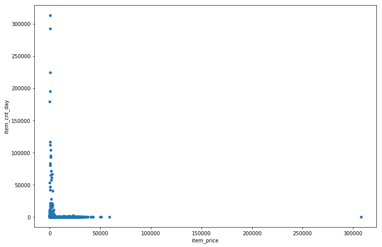

```python
data = train_postproc.groupby(['item_price'])['item_cnt_day'].sum().reset_index()
data.plot(x='item_price', y='item_cnt_day', kind='scatter', figsize=(12, 8))
```

### Total sales day by day

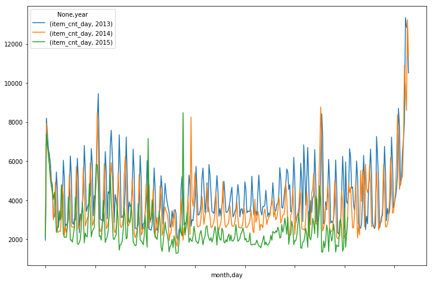

```python
data = train_postproc.groupby(['year', 'month', 'day']).agg({'item_cnt_day': np.sum}).unstack('year')
data.plot(figsize=(12, 8))
```

I believe there are some weekday/weekend trends as well.

### Total sales by shop

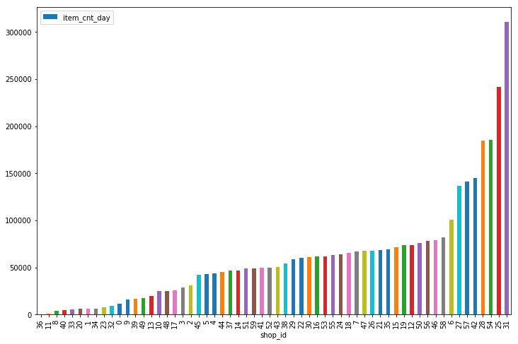

```python
data = train_postproc.groupby('shop_id')['item_cnt_day'].sum().sort_values().reset_index()
data.plot(x='shop_id', y='item_cnt_day', kind='bar', figsize=(12, 8))
```

### Total sales by shop split by year

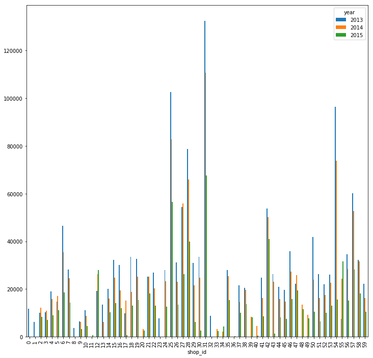

```python
data = train_postproc.groupby(['year', 'shop_id'])['item_cnt_day'].sum().sort_values().reset_index().\
    pivot(index='shop_id', columns='year', values='item_cnt_day')
data.plot(kind='bar', figsize = (12, 12))
```

### Frequency of item sale quantities

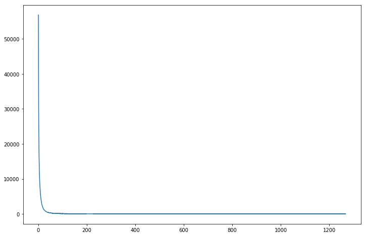

```python
data = train_postproc.groupby(['year', 'month', 'item_id'])['item_cnt_day'].count().reset_index()['item_cnt_day'].value_counts()
data.plot(figsize=(12, 8))
```

```python
data.describe()
```

```
count      546.000000
mean       428.410256
std       3121.719285
min          1.000000
25%          1.000000
50%          5.500000
75%         33.750000
max      56856.000000
Name: item_cnt_day, dtype: float64
```